# Chapter 5. Describing populations

**통계적 추론**은 제한된 관찰(표본)을 바탕으로 모집단에 대한 일반적인 결론을 유도하려는 시도(http://www.hellodatascience.com/?p=366)

인터넷을 조금만 찾아도, 공부하고자 하는 내용에 대해서 쉽게 풀어 써 놓은 사람들이 굉장히 많이 있습니다. 이번에는 책의 내용과 관련하여 사람들이 설명한 것들을 찾아 정리 해 두니, 한 번씩 읽어보시면 도움 될 것 같습니다.

## 5.1 Populations

**random variable, 확률변수** http://www.stat.yale.edu/Courses/1997-98/101/ranvar.htm

A *random variable* is defined as a *function* that **maps probability to a physical outcome (labels), typically real numbers**(Wikipedia).

이 말을 위키피디아에 나온 예를 가지고 쉽게 해석해 보겠습니다. 동전을 한 번 던진다고 할 때, 모든 가능한 사건 (확률 이론에서는 이걸 **sample space** 라고 합니다)은 $\Omega = \{앞면, 뒷면\}$ 입니다.

이제 *random variable* Y를 생각해 보겠습니다. 저 정의에 따르면 Y는 함수입니다. 그러니 사실 엄밀한 의미에서 Y의 표기는 Y(@)와 같이 해야 하겠지요. 이 함수 Y는 앞면이 나올 때 1달러를 받고, 뒷면이 나올 때 아무것도 받지 않는 조건을 나타낸다고 정하겠습니다. 그러면 이제 다음과 같은 관계가 성립됩니다.

$$Y(\omega) = 1, ~~if ~~\omega = heads~~~~~~Y(\omega) = 0, ~~if ~~\omega = tails$$

원래는 $\Omega$가 모든 가능한 **사건**들의 집합이기 때문에, 동전을 던졌을 때의 결과는 {앞면} 혹은 {뒷면}이 되어야 합니다.

그러나 우리는 결과가 앞면인지 뒷면인지에도 관심이 있지만, 결과를 통해 예측할 수 있는 다른 내용들에 대해서도 관심이 있습니다. 앞면이 나올 때 1달러를 받는다면, 동전을 10 번 던졌을 때 앞면이 나올 확률은 얼마일까요? 그렇게 되어서 제가 받는 금액(!)은 얼마나 될까요? 이런 수치적인 계산을 하기 위해서는, '앞면' 혹은 '뒷면' 이라는 문자가 아니라 계산에 사용될 수 있는 숫자가 필요합니다. 그렇기 때문에 임의로 '앞면' 이라는 결과를 1이라는 숫자에, '뒷면' 이라는 결과를 0이라는 숫자에 사상(mapping)을 시킵니다.

이제, Y 라는 random variable은 동전을 한 번 던져서 앞면이 나올 경우에 이 결과를 1이라는 숫자에 대응을 시키고, 뒷면이 나올 경우에 이 결과를 0이라는 숫자에 대응을 시키는 함수입니다. 이렇게 random variable이라는 건 우리가 실제로 관찰하는 현상을 실수 차원으로 옮겨와서 생각할 수 있게끔 하는 함수라고 이해하시면 되겠습니다.

$$P(Y(\omega)=1) = 7/10$$$$P(Y(\omega)=0) = 3/10$$

그리고 보통은 축약해서 $P(Y=1) = 7/10$, $P(Y=0) = 3/10$ 이라고 씁니다. 그렇지만 원래 엄밀한 표현은 위에 나온 표현들이라는 것을 기억하시면 되겠습니다.

우리는 또한 이전 챕터들에서 자료의 분포에 대해서 배웠습니다. 5장의 가장 첫 페이지에 나오는 **distribution of a random variable** 이라는 표현은, 이처럼 어떤 random variable이 특정한 값을 가질 확률을 나타내는 또 다른 함수를 나타냅니다. 함수는 정의역과 치역을 갖지요? 이 함수의 정의역은 확률변수가 가질 수 있는 값(우리의 예에서는 0과 1이 될 겁니다)이 되고, 치역은 그 값들이 갖는 확률이 되겠습니다.

### 5.1.1 Discrete random variables

이제 예시들을 살펴보겠습니다.

Example 5.1에 보면 역시 동전 던지기의 예시가 나와있고, 이번에는 두 번을 던집니다. 그러면 $\Omega = \{(앞면,앞면),(앞면,뒷면),(뒷면,앞면),(뒷면,뒷면)\}$이 됩니다.

X 라는 random variable을 정의해 보겠습니다. 이 random variable은 앞면이 나온 횟수만큼 1달러를 주는 조건을 나타낸다고 정의하겠습니다. 그러면 (앞면,앞면)의 사건에서는 2달러를 받을테고, (앞면,뒷면) 혹은 (뒷면,앞면)의 사건들에서는 1달러를 받을 것입니다. (뒷면,뒷면)의 사건에서는 0달러를 받겠지요.

위에서 언급했던 표기법으로 다시 정리해 보겠습니다.

$$\begin{aligned}&X(\omega) = 2, ~~if ~~\omega = (head, head)\\ &X(\omega) = 1, ~~if ~~\omega = (head, tail)~~or~~(tail, head)\\ &X(\omega) = 0, ~~if ~~\omega = (tail, tail)\end{aligned}$$

말씀드렸던 대로, 이는 엄밀한 표기법이고, 책에 나온 대로 줄여서 표현하면 X = 2, X = 1, X = 0 등으로 표현할 수 있겠습니다.

그러면 X 라는 함수의 값이 되는 2, 1, 0은 각각 동일한 확률로 관찰되는 값들이 아니라, 특정한 확률로 관찰이 됩니다. 동전을 두 번 던지는 것을 무수히 많이 한다고 해 보면, 2라는 값과 0이라는 값은 1/4의 확률로 관찰이 될 것이고, 1이라는 값은 2/4 = 1/2의 확률로 관찰이 될 것이라고 예측할 수 있습니다. 그렇기 때문에 책에 나온 바와 같이

$$\begin{aligned}&P(X(\omega) = 2) = P(X = 2) = 1/4\\ &P(X(\omega) = 1) = P(X = 1) = 1/2\\ &P(X(\omega) = 0) = P(X = 0) = 1/4\end{aligned}$$

라고 표현합니다.

Example 5.3을 보면, 확률 변수의 분포를 설정하는 방법을 이야기하고 있습니다. 우선 확률 변수가 가질 수 있는 값의 범위를 설정하고, 각 값 k에 대하여 k가 나타날 확률 $p_k = P(X=k)$를 설정하는 것이지요. 확률의 정의에 따라 $p_k >= 0$ 이고, $\sum{p_k} = 1$입니다.

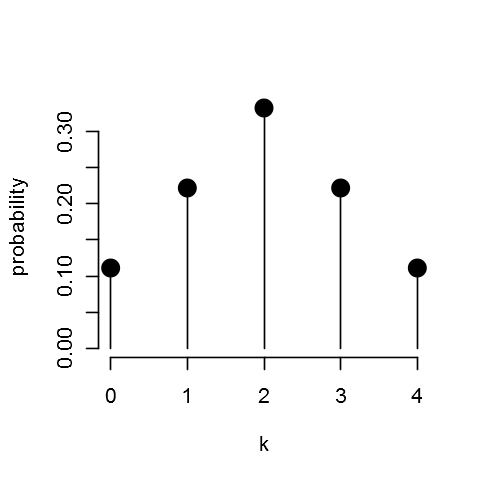

```r
options(repr.plot.width=4, repr.plot.height=4)
k <- 0:4
p <- c(1,2,3,2,1)/9 # p = {1/9, 2/9, 3/9, 2/9, 1/9}, sum(p) equals 1
plot(k, p, type="h", xlab="k", ylab="probability", ylim=c(0, max(p)), bty="n")
points(k, p, pch=16, cex=2)
```

[참고] sample() 함수의 사용

sample() 함수는 이산확률변수(discrete random variable)의 관찰 값을 생성하는 함수입니다.  
쉽게 말해, X 라는 확률 변수가 0,1,2,3,4 라는 값을 가질 수 있다고 하고, 각 값은 1/6, 1/6, 2/6, 1/6, 1/6의 확률을 가진다고 해 보겠습니다.

sample() 함수는 k, size, prob 등의 매개변수를 가지고 있습니다. k는 확률변수가 가질 수 있는 값들을 저장한 벡터입니다. prob은 각 값이 가지는 확률값들을 저장한 벡터입니다. size는 추출할 확률 변수의 개수를 나타내기 때문에 상수 값을 설정하면 됩니다.

```r
k <- c(0,1,2,3,4)
p <- c(1,1,2,1,1)/6
sample(k,size=1, prob=p)
```

2

```r
sample(k, size=3, prob=p)
```

1. 3

2. 1

3. 4

3, 1, 4가 나왔습니다. 이것은 제가 size=3 이라고 설정했기 때문입니다. 그리고 말씀드린대로 값의 추출은 확률을 고려하여 무작위로 뽑는 것이기 때문에 똑같은 식을 써도 다른 결과가 나올 것입니다.

```r
sample(k, size=3, prob=p)
```

1. 0

2. 4

3. 2

이번에는 0, 4, 2가 나왔습니다. 이처럼 sample() 함수는 매번 무작위로 확률만을 고려하여 확률 변수가 가질 수 있는 값들을 추출하기 때문에, 결과가 매번 다르게 출력됩니다. 만약 매번 같은 결과를 출력하고 싶을 때에는 set.seed(n) 라는 함수를 먼저 써 주시면 됩니다. n은 일반 상수(1, 2....)입니다.

```r
set.seed(1)
sample(k, size=3, prob=p)
print(sample(k, size=3, prob=p))
```

1. 2

2. 3

3. 4

```
[1] 0 2 4
```

```r
set.seed(2)
sample(k, size=3, prob=p)
```

1. 2

2. 4

3. 3

```r
set.seed(1)
sample(k, size=3, prob=p)
```

1. 2

2. 3

3. 4

set.seed(1) 아래의 sample 함수를 사용한 결과들은 모두 2, 3, 4가 나오는 것을 확인할 수 있습니다. 이 때 주의할 점은, set.seed(1)는 바로 밑의 줄에만 영향을 끼친다는 점입니다. 예를 들어, print(sample(k, size=3, prob=p))는 그 위에 있는 명령문과 똑같지만, set.seed(1) 이라는 명령문의 영향을 받지 않기 때문에 0, 2, 4 라는 숫자가 출력되게 됩니다.

[참고 2] 이산확률변수의 평균과 표준 편차

이전에 살펴보았던 평균과 표준 편차의 개념은 확률 변수들에 대해서도 적용이 됩니다. 확률 변수들은 가질 수 있는 값들이 여럿 있으니, 당연히 그 값들의 평균을 구할 수 있을 것이고 값들의 표준 편차도 구할 수 있을 겁니다. 그러나 확률 변수에서는 평균과 표준편차의 정의가 조금 달라집니다.

**모집단의 평균(population mean)**은 그리스어 $\mu$ 로 표기합니다. 어떤 모집단에 대하여 X 라는 확률 변수를 설정하면, 이 때 X의 평균은 **X의 기대값**이라고 하기도 합니다.

다시 동전을 두 번 던지는 예로 돌아가보겠습니다. 모집단은 $\Omega = \{(H,H), (H,T), (T,H), (T,T)\}$ 입니다. 이제 모집단을 X 라는 임의의 확률 변수를 적용하여 살펴보겠습니다. X를 뒷면이 나온 횟수만큼 1달러를 주는 것이라고 정의하겠습니다.

$X(\omega) = \{0, 1, 2\}, ~~ P(X(\omega) = 0) = 1/4, ~~P(X(\omega) = 1) = 2/4,~~ P(X(\omega) = 2) = 1/4$가 될 겁니다.

X가 가질 수 있는 값은 0, 1, 2 세 가지 뿐이지만, 이 세 가지는 각각 관찰될 확률이 다릅니다. 0, 2가 한 번씩 관찰 될 때 1은 두 번 관찰 될 수 있지요. 원래 모집단에 네 가지 사건이 있었던 것 처럼, X도 사실은 네 가지 값을 가진다고 생각하시면 될 겁니다. 0,1,1,2 이렇게요.

0,1,1,2의 평균은 (0+1+1+2)/4 = 1 입니다. 이것이 곧 모집단 수준에서 X의 평균이지요. 아까 평균은 기대값이라고도 표현한다고 했습니다. 기대값이란, 책의 (5.1)에 나온 공식대로 X 라는 확률 변수가 가질 수 있는 값들에 각각 그 값들이 관찰될 확률을 곱해서 모두 더해주는 것을 말합니다.

$$\mu = E[X(\omega)] = \sum_{k}{kP(X(\omega) = k)}$$

계산결과는 0*(1/4)+1*(1/2)+2*(1/4) = 0+(1/2)+(1/2) = 1이라는 평균의 결과와 동일합니다.

**모집단의 표준편차(population standard deviation)**은 그리스어 $\sigma$로 표기합니다. 표준편차는 분산의 제곱근이기 때문에, 분산은 $\sigma^2$로 나타냅니다. 확률 변수의 경우, $\sigma^2 = VAR[X(\omega)] = E[(X(\omega) - \mu)^2]$입니다.